# Hospital admissions

For the present analysis I’ve been looking for the rate of hospital admissions among 211.367 patients from June 2013 to July 2018. In that period 21.235 hospital admissions happened, 2.019 were due to conditions sensitive to ambulatory care.

190.420 (90.0%) were never hospitalized and 20.947 (10.0%) were hospitalized at least once.

The linkage between the hospital admition dataset and the EMR dataset is not finished yet and most likely it will change the confidence intervals.

The unit of analysis was a Family Health Team (FHT) in a month with the exposure affecting the FHT. For every FHT we have the variables “month”, “number of patients”, “number of consultations”, “number of adults”, “number of patients referred to secondary care”, “number of pregnant women”, “social development index”, “number of hospital admittions”, “number of ACSC” and one variable for each group of ACSC.

### Social Development Index

#### Sanitation

percentage of households with access to treated water;  
percentage of households with access to sewage system;  
percentage of households with garbage collection service;

#### Housing

average number of toillets per household

#### Schooling

percentage of illetarate people above 15 years old  
percentage of main providers with less than four years of schooling  
percentage of main providers with more than 15 years of schooling

#### Income

average household income (in minimum wage)  
percentage of main providers with less than two times the minimum wage  
percentage of main providers with more than ten times the minimum wage

```r
library(tidyverse)
library(lubridate)
load("C:\\Users\\user\\Desktop\\pendrive\\novo_prime\\csaps_todos.RData")
```

| exps | Hospitalized | ACSC |
| --- | --- | --- |
| Generalist | 12755 | 1239 |
| FP | 8480 | 780 |

Risk of being diagnosed with a condition regarding to the type of doctor in charge adjusted by the social development index and time. Rio de Janeiro, 2013 to 2018

Total Hospital admissions

Ambulatory care sensitive conditions

Predictors

IRR

IRR

Family Physician

0.96 *  
(0.93 – 0.99)

0.93  
(0.84 – 1.02)

Social Development Index

1.38  
(0.97 – 1.97)

21.01 ***  
(7.04 – 61.84)

Month

1.00 ***  
(1.00 – 1.00)

1.00 ***  
(1.00 – 1.00)

Referrals

1.04 ***  
(1.03 – 1.06)

1.07 **  
(1.03 – 1.12)

Consults

1.00 *  
(1.00 – 1.00)

1.00  
(1.00 – 1.00)

Observations

2808

2808

- p<0.05 ** p<0.01 *** p<0.001

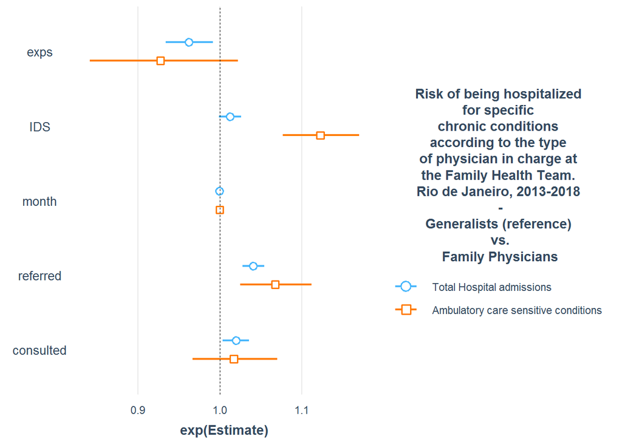

## Nutrition, Preventable, Gastroenteritis, Anemia

| exps | imunization | preventable | gastroenteritis | anemia | nutrition |
| --- | --- | --- | --- | --- | --- |
| Generalist | 2 | 22 | 35 | 5 | 6 |
| FP | 0 | 18 | 21 | 2 | 3 |

Risk of being diagnosed with a condition regarding to the type of doctor in charge adjusted by the social development index and time. Rio de Janeiro, 2013 to 2018

Nutrition

Preventable

Gastroenteritis

Anemia

Predictors

IRR

IRR

IRR

IRR

Family Physician

0.71  
(0.15 – 2.70)

1.22  
(0.64 – 2.26)

0.88  
(0.50 – 1.50)

0.54  
(0.08 – 2.55)

Social Development Index

0.00  
(0.00 – 33203.57)

122.46  
(0.06 – 152552.52)

4.39  
(0.00 – 2434.39)

0.00  
(0.00 – 125054.88)

Month

1.00  
(1.00 – 1.00)

1.00  
(1.00 – 1.00)

1.00 *  
(1.00 – 1.00)

1.00  
(1.00 – 1.00)

Observations

2830

2830

2830

2830

- p<0.05 ** p<0.01 *** p<0.001

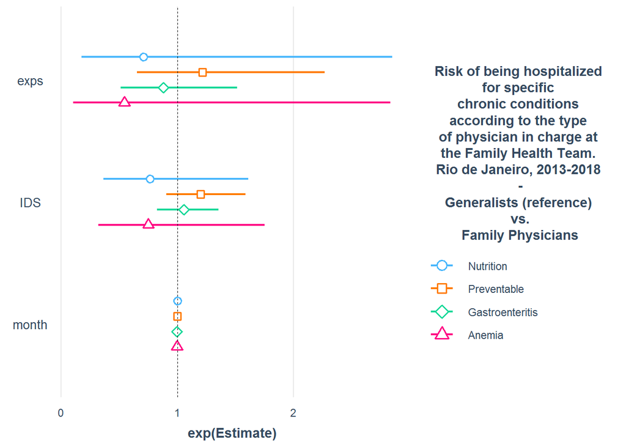

## Upper Respiratory Tract Infection, Pneumonia, Asthma, Lower Respiratory Tract Infection

| exps | URTI | pneumonia | asthma | LRTI |
| --- | --- | --- | --- | --- |
| Generalist | 15 | 126 | 18 | 45 |
| FP | 15 | 86 | 10 | 40 |

Risk of being diagnosed with a condition regarding to the type of doctor in charge adjusted by the social development index and time. Rio de Janeiro, 2013 to 2018

Upper Respiratory Tract Infection

Pneumonia

Asthma

Lower Respiratory Tract Infection

Predictors

IRR

IRR

IRR

IRR

Family Physician

1.45  
(0.70 – 3.00)

1.02  
(0.77 – 1.34)

0.82  
(0.37 – 1.76)

1.31  
(0.85 – 2.00)

Social Development Index

0.59  
(0.00 – 3958.23)

34.21 *  
(1.21 – 852.31)

1.50  
(0.00 – 14293.79)

0.10  
(0.00 – 25.51)

Month

1.00  
(1.00 – 1.00)

1.00 *  
(1.00 – 1.00)

1.00  
(1.00 – 1.00)

1.00  
(1.00 – 1.00)

Referrals

1.02  
(0.66 – 1.43)

1.09  
(0.94 – 1.24)

1.16  
(0.79 – 1.55)

1.09  
(0.88 – 1.33)

Observations

2830

2830

2830

2830

- p<0.05 ** p<0.01 *** p<0.001

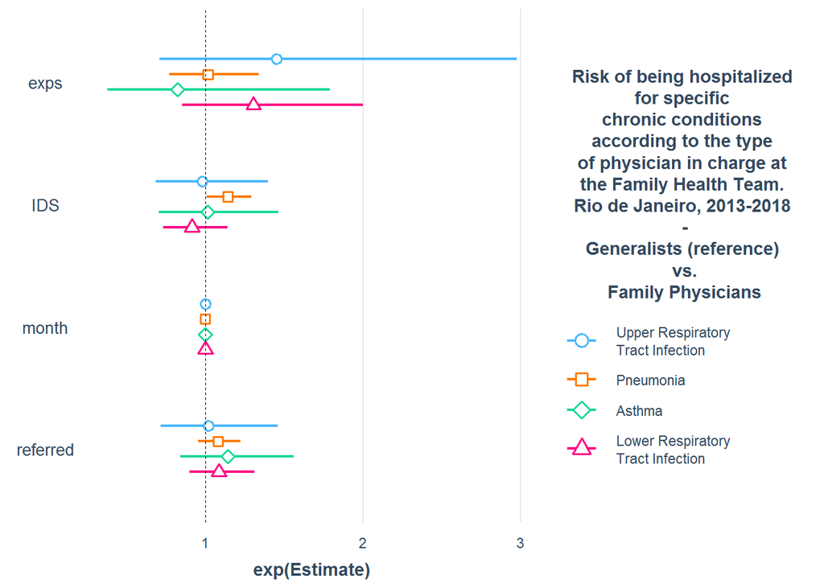

## Hypertension, Stroke, Angina, Heart Failure, Diabetes

| exps | HT | angina | HF | DM | stroke |
| --- | --- | --- | --- | --- | --- |
| Generalist | 28 | 70 | 115 | 91 | 113 |
| FP | 19 | 43 | 55 | 39 | 47 |

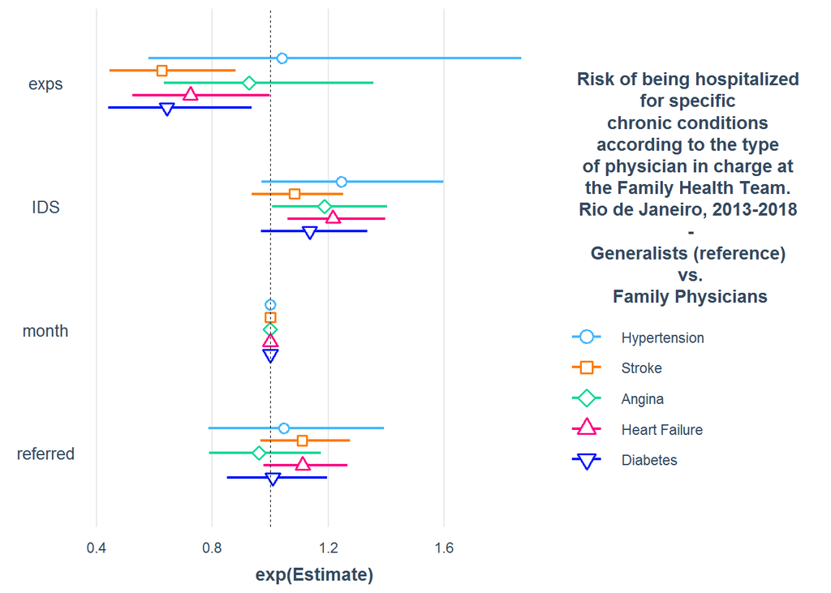

Risk of being diagnosed with a condition regarding to the type of doctor in charge adjusted by the social development index and time. Rio de Janeiro, 2013 to 2018

Hypertension

Stroke

Angina

Heart Failure

Diabetes

Predictors

IRR

IRR

IRR

IRR

IRR

expsFP

1.04  
(0.57 – 1.85)

0.63 **  
(0.44 – 0.87)

0.93  
(0.63 – 1.35)

0.72 *  
(0.52 – 0.99)

0.64 *  
(0.44 – 0.93)

IDS

322.43  
(0.34 – 196317.34)

8.14  
(0.16 – 351.24)

95.60 *  
(1.09 – 6920.17)

176.13 **  
(4.28 – 6424.13)

28.91  
(0.38 – 1853.55)

month

1.00 **  
(1.00 – 1.00)

1.00 ***  
(1.00 – 1.00)

1.00 **  
(1.00 – 1.00)

1.00  
(1.00 – 1.00)

1.00  
(1.00 – 1.00)

referred

1.05  
(0.74 – 1.39)

1.12  
(0.95 – 1.29)

0.96  
(0.76 – 1.17)

1.12  
(0.97 – 1.28)

1.01  
(0.83 – 1.20)

Observations

2830

2830

2830

2830

2830

- p<0.05 ** p<0.01 *** p<0.001

## Epilepsy, Urinary Tract Infection, Skin infection

| exps | epilepsy | UTI | skin_infection | PID | peptic_ulcer | prenatal | csaps | IDS_mean | IDS_sd |
| --- | --- | --- | --- | --- | --- | --- | --- | --- | --- |
| Generalist | 47 | 136 | 232 | 26 | 42 | 65 | 1239 | 0.591543 | 0.0357560 |
| FP | 26 | 84 | 172 | 21 | 40 | 39 | 780 | 0.588017 | 0.0408902 |

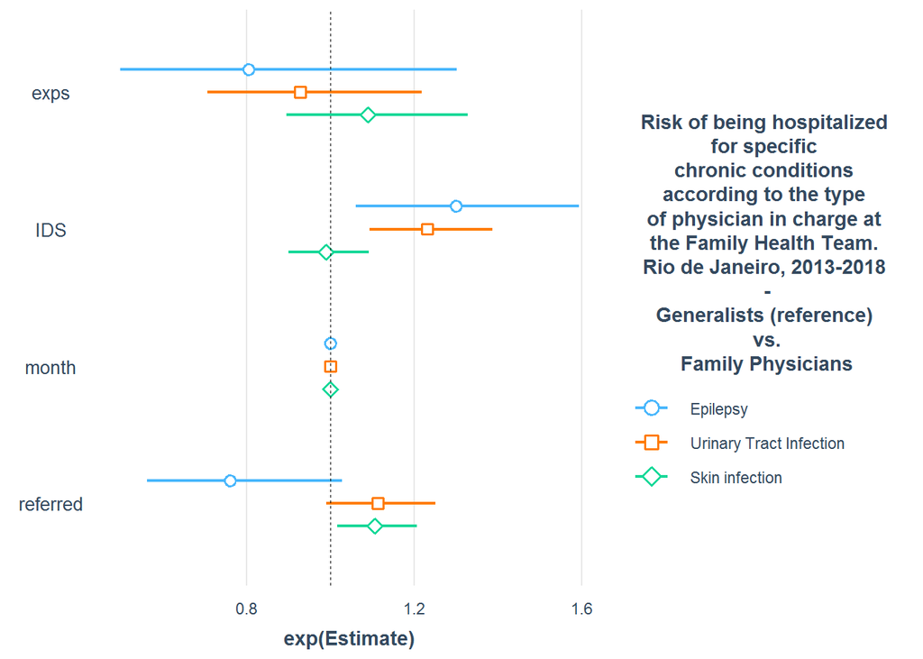

Risk of being diagnosed with a condition regarding to the type of doctor in charge adjusted by the social development index and time. Rio de Janeiro, 2013 to 2018

Epilepsy

Urinary Tract Infection

Skin infection

Predictors

IRR

IRR

IRR

Family Physician

0.81  
(0.49 – 1.29)

0.93  
(0.70 – 1.22)

1.09  
(0.89 – 1.33)

Social Development Index

1018.56 *  
(4.08 – 197876.12)

243.49 ***  
(9.98 – 5360.67)

0.78  
(0.06 – 9.64)

Month

1.00  
(1.00 – 1.00)

1.00  
(1.00 – 1.00)

1.00  
(1.00 – 1.00)

Referrals

0.74  
(0.52 – 1.00)

1.12  
(0.98 – 1.27)

1.12 *  
(1.01 – 1.22)

Observations

2830

2830

2830

- p<0.05 ** p<0.01 *** p<0.001

## Pelvic inflammatory disease, Peptic ulcer, Prenatal

| exps | PID | peptic_ulcer | prenatal |
| --- | --- | --- | --- |
| Generalist | 26 | 42 | 65 |
| FP | 21 | 40 | 39 |

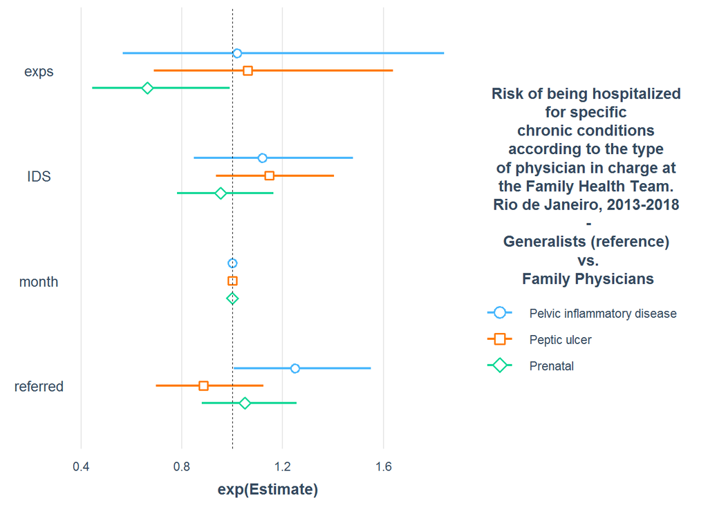

Risk of being diagnosed with a condition regarding to the type of doctor in charge adjusted by the social development index and time. Rio de Janeiro, 2013 to 2018

Pelvic inflammatory disease

Peptic ulcer

Prenatal

Predictors

IRR

IRR

IRR

expsFP

1.02  
(0.56 – 1.84)

1.06  
(0.69 – 1.64)

0.66 *  
(0.44 – 0.98)

IDS

19.74  
(0.01 – 21847.13)

36.59  
(0.15 – 6702.95)

0.28  
(0.00 – 44.35)

month

1.00 **  
(1.00 – 1.00)

1.00  
(1.00 – 1.00)

1.00 ***  
(1.00 – 1.00)

referred

0.88  
(0.66 – 1.11)

1.05  
(0.86 – 1.26)

Observations

2806

2808

2806

- p<0.05 ** p<0.01 *** p<0.001

## Next steps

1 - Finish the linkage;

2 - Look for hospital admissions due to mental health conditions;

3 - Screen all codes used, beyond those groups listed as sensitive to ambulatory care;

5 - Use information from lab results and prescription (finally ready to use) and use them to adjust the models for Diabetes, Heart Failure, Stroke and Hypertension.

### Next meeting December 19th?